# SMC Report Engine - How To

# SMC Report Engine — How To

**Location:** `~/ZDST-TEST-2/SMC/` on the NG-central JupyterHub (`https://bauchi-hcm.digit.org/jupyter/user/reportsadmin/`)

This engine generates SMC campaign reports for all 10 Nigerian states from one shared set of scripts. You pick a state, tick the reports you want, choose either a cycle or a date range, and press a button. There is no per-state copy of anything.

```
SMC/
├── START_HERE_SMC.ipynb          <- the only file a report user opens
└── _engine/
    ├── report_ui.py              <- the form, progress, Stop button, download links
    ├── campaign-config.json      <- which states exist, and which reports each one gets
    ├── reports_config.json       <- the report catalog (script path, output name, filters)
    ├── reports_date_config.json  <- written automatically on every run; do not hand-edit
    ├── COMMON_UTILS/
    │   ├── common_utils.py       <- get_resp (ES calls + cycle injection), save_excel
    │   ├── tenant.py             <- PREFIX / CAMPAIGN / es_index() for the selected state
    │   └── custom_date_utils.py  <- reads the reporting window
    ├── REPORTS_SCRIPTS/
    │   ├── children_treated/child_treatment_report.py
    │   ├── ri_report/ri_report.py
    │   ├── ors_report/ors_report.py
    │   └── stock_report/stock_report.py
    └── FINAL_REPORTS/<state>/    <- generated workbooks land here
```

# 1. How to generate reports

### Step 1 — open the notebook

In the JupyterLab file browser open **`ZDST-TEST-2/SMC/START_HERE_SMC.ipynb`**.

### Step 2 — run the single cell

Click the cell and press **Shift+Enter**. That is the only cell, and its only job is to launch the form:

```python
import os, sys, importlib
sys.path.insert(0, os.path.join(os.getcwd(), '_engine'))
import report_ui; importlib.reload(report_ui)
report_ui.launch(debug=False)   # set debug=True for full logs
```

If nothing appears, the kernel is not connected yet — wait for the kernel indicator to go idle and run the cell again.

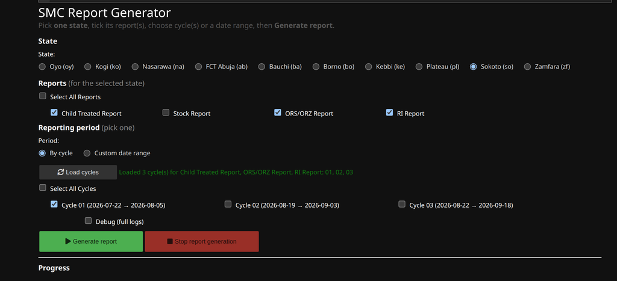

### Step 3 — pick one state

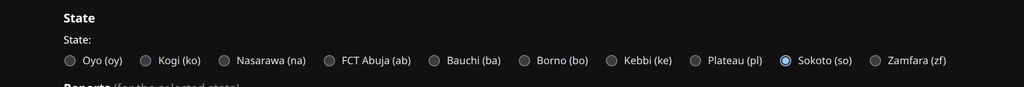

One state per run. The tenant prefix in brackets (`ba`, `zf`, `so` …) is the Elasticsearch index prefix that the scripts will read.

### Step 4 — tick the reports you want

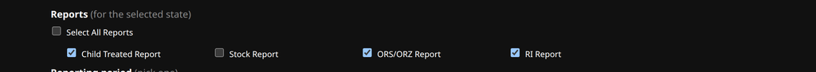

### Step 5 — choose the period

Two modes:

**By cycle (recommended).** Press **Load cycles**. The engine queries live data and shows only the cycles that actually contain data *for the reports you ticked*, with each cycle's real date span. Tick one or more.

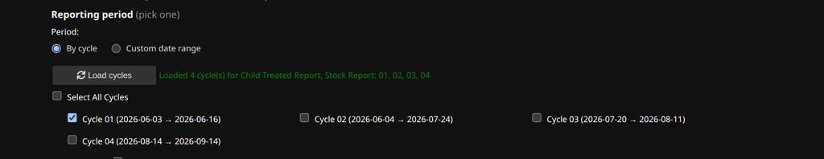

Selecting several cycles reports across the whole combined span.

**Custom date range.** Switch the Period radio to *Custom date range* and pick From/To.

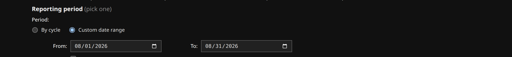

> In cycle mode the date window is deliberately ignored (the engine writes a wide-open 2000–2099 window so the cycle alone scopes the data). In date mode there is no cycle filter and the dates apply. Use one or the other, not both.

### Step 6 — Generate report

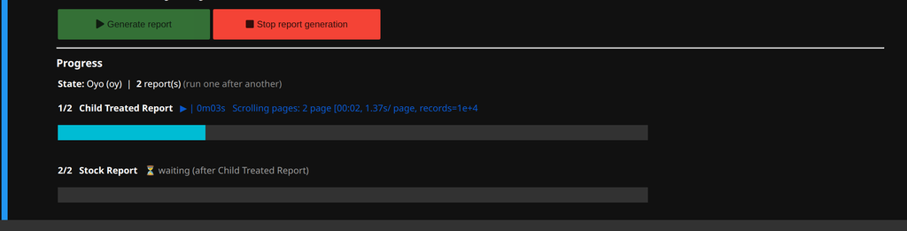

Progress is shown per report, with the elapsed time and the current `[Step x/y]`. Reports run **one after another**, not in parallel — the queued ones show ⏳ *waiting*.

Once fetching hits 100% the Excel write stage begins, and on a large report that stage alone can take a few minutes. It is not stuck: the label switches to a row counter, e.g.

```
[save_excel] 50,000/256,830 rows written (19%) -> CHILDREN_TREATED.xlsx
```

**Stop report generation** terminates the running report. Partial output is deleted, so you never receive a truncated workbook.

### Step 7 — download

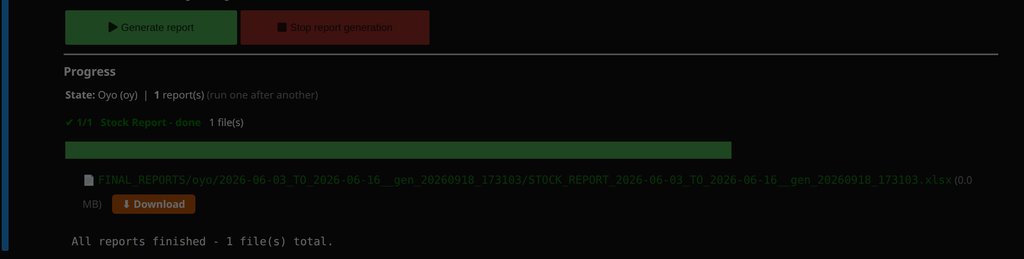

Each finished file is listed with its size and an orange **⬇ Download** button. You can also find the files in `SMC/FINAL_REPORTS/<state>/`.

Reports over **1,000,000 rows** are split automatically into `<name>_part1.xlsx`, `<name>_part2.xlsx`, … Excel cannot hold more than ~1,048,576 rows in one sheet.

# 2. How to add a new report — common to all states

Two files to touch, plus the script itself. Worked example: the Stock report, added this way.

### Step 1 — write the script

Create `_engine/REPORTS_SCRIPTS/<your_report>/<your_report>.py`. Follow §5 — the rules there are what make one script work for ten states.

### Step 2 — register it in the catalog

`_engine/reports_config.json`:

```json
{
  "Stock Report": {
    "input":    "/REPORTS_SCRIPTS/stock_report/",
    "scripts":  ["stock_report.py"],
    "filename": ["STOCK_REPORT.xlsx"],
    "cycle_index": "stock"
  }
}
```

[output not shown]

### Step 3 — make it common

`_engine/campaign-config.json`:

```json
{
  "campaign_type": "SMC",
  "common_reports": ["Child Treated Report", "Stock Report"],
  "states": { "...": "..." }
}
```

Anything in `common_reports` is offered for **every** state. That is the whole change — no per-state edits.

### Step 4 — verify before telling anyone

```bash
cd ~/ZDST-TEST-2/SMC/_engine
python3 -c "import py_compile;py_compile.compile('REPORTS_SCRIPTS/stock_report/stock_report.py',doraise=True)"

# run it exactly as the UI does: state via env, cycle via env
STATE_CODE=zamfara CYCLES=02 python3 REPORTS_SCRIPTS/stock_report/stock_report.py
```

Then run it for a second state to prove nothing is state-specific, and confirm two different cycles give two different results (if they don't, your cycle filter isn't working — see §5.2).

# 3. How to add a new report — specific states only

Same script and same catalog entry as §2. The only difference: instead of adding it to `common_reports`, list it under the states that should have it.

`_engine/campaign-config.json`:

```json
{
  "common_reports": ["Child Treated Report", "Stock Report"],
  "states": {
    "kogi": {
      "name": "Kogi",
      "tenant_id": "ko",
      "campaign_number": "CMP-2026-06-03-000315",
      "extra_reports": ["RI Report"]
    },
    "sokoto": {
      "name": "Sokoto",
      "tenant_id": "so",
      "campaign_number": "CMP-2026-07-22-000449",
      "extra_reports": ["ORS/ORZ Report", "RI Report"]
    },
    "oyo": {
      "name": "Oyo",
      "tenant_id": "oy",
      "campaign_number": "CMP-2026-06-03-000308"
    }
  }
}
```

A state's report list is `common_reports + its own extra_reports`. Oyo has no `extra_reports`, so it sees only the two common ones.

The name in `extra_reports` **must match the catalog key exactly**, including spaces and punctuation — `"ORS/ORZ Report"`, not `"ORS Report"`.

# 4. How to add a new report — specific states, specific cycles only

This one works differently from §2 and §3, and the difference matters.

**Cycles are never listed in config.** They are discovered from live data every time the user presses *Load cycles*. This is deliberate: a hardcoded cycle in the old per-state RI script was silently discarding 79% / 73% / 86% of Kogi / Plateau / Sokoto's RI records, because those states carry RI data in different cycles.

You restrict a report to certain cycles by declaring **what its data looks like**, using `cycle_filter` in `reports_config.json`. The engine then shows only the cycles where that filter actually matches data, per state.

```json
{
  "RI Report": {
    "input":    "/REPORTS_SCRIPTS/ri_report/",
    "scripts":  ["ri_report.py"],
    "filename": ["RI_Report.xlsx"],
    "cycle_filter": { "term": { "Data.additionalDetails.flow.keyword": "riDone" } }
  },
  "ORS/ORZ Report": {
    "input":    "/REPORTS_SCRIPTS/ors_report/",
    "scripts":  ["ors_report.py"],
    "filename": ["ORSZ_TREATED.xlsx"],
    "cycle_filter": { "term": { "Data.productName.keyword": "ORS-Zinc" } }
  }
}
```

`cycle_filter` may be a single clause or a list of clauses; they are ANDed into the discovery query's `must`.

### What that produces today

Live, as configured right now — note how the same report offers different cycles in different states, with no static configuration anywhere:

| state | report | cycles offered |
| --- | --- | --- |
| oyo | Child Treated, Stock | 01, 02, 03, 04 |
| kogi | Child Treated, Stock | 01, 02, 03, 04 |
| kogi | **RI** | **02, 03, 04** — no RI data in cycle 01 |
| nasarawa | Child Treated, Stock | 01, 02, 03, 04 |
| fct_abuja | Child Treated, Stock | 01, 02, 03, 04 |
| bauchi | Child Treated, Stock | 01, 02, 03, 04 |
| borno | Child Treated, Stock | 01, 02, 03 |
| kebbi | Child Treated, Stock | 01, 02, 03 |
| kebbi | **ORS/ORZ** | **01, 03** — no ORS-Zinc in cycle 02 |
| plateau | Child Treated, Stock | 01, 02, 03, 04 |
| plateau | **RI** | 01, 02, 03, 04 |
| sokoto | Child Treated, Stock | 01, 02, 03 |
| sokoto | **ORS/ORZ** | **01, 03** |
| sokoto | **RI** | **02, 03** |
| zamfara | Child Treated, Stock | 01, 02, 03 |

A cycle is listed only if it holds at least `CYCLE_MIN_DOCS` (100) matching documents, which keeps stray test records out of the list.

### If you need a hard cycle restriction

There is currently **no** config key that pins a report to an explicit cycle list for a given state — and in most cases you should not want one, because `cycle_filter` already produces the correct answer from the data. If you have a genuine case (for example a cycle whose data is known-bad and must not be reportable), that needs a small engine change in `report_ui._load_cycles` — roughly:

```json
"My Report": { "cycle_allow": { "sokoto": ["02", "03"] } }
```

Raise it as a change request rather than hardcoding a cycle inside a report script. A cycle hardcoded in a script cannot be seen from the UI and is exactly how the RI data-loss bug happened.

# 5. Script conventions

Every report script must follow these, or it will work for one state and quietly break for the other nine.

### 5.1 Never hardcode tenant or campaign

```python
from COMMON_UTILS.tenant import PREFIX, CAMPAIGN, es_index

CAMPAIGN_NUMBER = CAMPAIGN          # resolved from the selected state
ES_STOCK_INDEX  = es_index("stock") # -> https://…/<prefix>-stock-index-v1/_search
```

`tenant.py` reads `STATE_CODE` from the environment (the UI sets it) and looks the state up in `campaign-config.json`. It raises if the state is not configured, so a typo fails loudly.

### 5.2 Never hardcode the cycle — and never keep your own cycle clause

`get_resp` injects the user's cycle selection into your query, but **only if the query has no cycle clause of its own**:

```python
present = any(key in m.get("terms", {}) or key in m.get("term", {}) for m in arr)
if not present:
    arr.append({"terms": {key: cycle_terms(cyc)}})
```

So a leftover `{"term": {"Data.additionalDetails.cycleIndex.keyword": "02"}}` does not merely duplicate the filter — it **suppresses injection entirely** and pins every run to cycle 02 regardless of what the user ticked. Leave the cycle out of your query completely.

Injection only applies to fact indexes:

```python
CYCLE_INDEXES = ("project-task-index", "hf-referral-index", "referral-index",
                 "stock-index", "crosscycle-index")
```

Lookup indexes (`individual`, `household-member`, `household`, `project-beneficiary`) are deliberately excluded — filtering them by cycle breaks the `clientReferenceId` join and blanks out Child Name / Household Head Name.

Your query must be a dict with `query.bool.must` (or `.filter`) as a **list**, or injection cannot find a place to add the clause.

### 5.3 Take the reporting window from the shared helper

```python
from COMMON_UTILS.custom_date_utils import get_custom_dates_of_reports
lteTime, gteTime, start_date_str, end_date_str = get_custom_dates_of_reports()
...
{"range": {"Data.@timestamp": {"gte": gteTime, "lte": lteTime}}}
```

Use `Data.@timestamp` — that is what all four existing reports use. In cycle mode this is a no-op; in date mode it is the filter.

### 5.4 Write output only through `save_excel`

```python
from COMMON_UTILS.common_utils import save_excel
save_excel(df, out_path)                                  # single sheet
save_excel(df, out_path, extra_sheets={"Summary": sdf})   # extra sheets go in file 1
```

This gives you xlsxwriter `constant_memory` streaming, automatic >1M-row part-file splitting, and a loud failure if no Excel engine is present. **Do not** use `df.to_excel`, `pd.ExcelWriter`, `to_csv`, or openpyxl directly — you would lose the row-limit protection and silently change the delivered format.

### 5.5 Put every tunable in one CONFIG block

One `# ===== CONFIG =====` block near the top: campaign, index URLs, page sizes, filter value lists, output directory and filename. Define the ES host **once**. The next person should be able to retune the report without reading the body.

### 5.6 Print `[Step x/y]` markers

```python
log("[Step 1/5] Fetching State Facility -> HF (ISSUED) ...")
```

The UI parses `Step n/m` to drive its progress bar and to keep the label honest during long silent stages.

### 5.7 Resolve paths from `__file__`, never the working directory

```python
file_path = os.path.dirname(os.path.dirname(os.path.dirname(os.path.abspath(__file__))))
OUTPUT_DIR = os.path.join(file_path, "FINAL_REPORTS", "STOCK")
```

### 5.8 Fail loudly, never silently empty

If a query returns nothing, say so. A report that writes a valid but empty workbook without comment looks identical to a successful run.

# 6. Config reference

### `campaign-config.json`

```json
{
  "campaign_type": "SMC",
  "common_reports": ["Child Treated Report", "Stock Report"],
  "states": {
    "<state_code>": {
      "name": "Display Name",
      "tenant_id": "xx",
      "campaign_number": "CMP-…",
      "extra_reports": ["Optional Report"]
    }
  }
}
```

### `reports_config.json`

```json
{
  "<Report Name>": {
    "input": "/REPORTS_SCRIPTS/<folder>/",
    "scripts": ["<script>.py"],
    "filename": ["<OUTPUT>.xlsx"],
    "cycle_index": "stock",
    "cycle_filter": { "term": { "<field>.keyword": "<value>" } }
  }
}
```

### Environment the UI sets for each script

| Variable | Example | Meaning |
| --- | --- | --- |
| `STATE_CODE` | `zamfara` | selected state; `tenant.py` resolves prefix + campaign |
| `CYCLES` | `01,02` | ticked cycles, empty in date mode |

### `reports_date_config.json`

Rewritten automatically before every run — **do not hand-edit it.** In cycle mode it gets `2000-01-01 … 2099-12-31` so the date filter is inert; in date mode it gets the picked dates. It is the handoff channel between the UI and the scripts, not a settings file.

# 7. Troubleshooting

[output not shown]

## Appendix — verifying a change without the UI

```bash
cd ~/ZDST-TEST-2/SMC/_engine

# compile everything
python3 - <<'EOF'
import glob, py_compile
for p in glob.glob('**/*.py', recursive=True):
    py_compile.compile(p, doraise=True)
print("all modules compile")
EOF

# cycle mode, one state, one cycle
STATE_CODE=zamfara CYCLES=02 python3 REPORTS_SCRIPTS/stock_report/stock_report.py

# prove the cycle filter is live: these must differ
STATE_CODE=zamfara CYCLES=01 python3 REPORTS_SCRIPTS/stock_report/stock_report.py
STATE_CODE=zamfara CYCLES=03 python3 REPORTS_SCRIPTS/stock_report/stock_report.py
```

Always test a second state before shipping. One state passing proves nothing about the per-tenant wiring.